# titanic-machine-learning-from-disaster

```python
# This Python 3 environment comes with many helpful analytics libraries installed
# It is defined by the kaggle/python docker image: https://github.com/kaggle/docker-python
# For example, here's several helpful packages to load in

import warnings
warnings.filterwarnings('ignore')

import numpy as np # linear algebra
import pandas as pd # data processing, CSV file I/O (e.g. pd.read_csv)

# plotly
import plotly.plotly as py
from plotly.offline import init_notebook_mode, iplot
init_notebook_mode(connected=True)
import plotly.graph_objs as go
from plotly import tools

# matplotlib
import matplotlib.pyplot as plt

# Input data files are available in the "../input/" directory.
# For example, running this (by clicking run or pressing Shift+Enter) will list the files in the input directory

import os
print(os.listdir("Data"))

# Any results you write to the current directory are saved as output.
```

```
['gender_submission.csv', 'submission.csv', 'test.csv', 'train.csv']
```

## Titanic: Machine Learning from Disaster

This kernel shows an approach for prediction of survival of a person on the Titanic. It gives a comparison of Neural Network (NN) using Sequential Model from Keras API for TensorFlow and Random Forest Classifier (RF) from scikit-learn.

Further, I will be using Hyperparameter Opimization technique, Grid Search for the NN model and Random Search for RF model.

## 1. Data Understanding

First let us take a look at how our data looks like, to get more details on the characteristics of the attributes/features.

**1.1 Peek into the Data:**

```python
# Reading the train and the test data.
trainData = pd.read_csv('Data/train.csv')
testData = pd.read_csv('Data/test.csv')

# Displaying a sample of the train data to get more detailed info
trainData.head()
```

|  | PassengerId | Survived | Pclass | Name | Sex | Age | SibSp | Parch | Ticket | Fare | Cabin | Embarked |
| --- | --- | --- | --- | --- | --- | --- | --- | --- | --- | --- | --- | --- |
| 0 | 1 | 0 | 3 | Braund, Mr. Owen Harris | male | 22.0 | 1 | 0 | A/5 21171 | 7.2500 | NaN | S |
| 1 | 2 | 1 | 1 | Cumings, Mrs. John Bradley (Florence Briggs Th... | female | 38.0 | 1 | 0 | PC 17599 | 71.2833 | C85 | C |
| 2 | 3 | 1 | 3 | Heikkinen, Miss. Laina | female | 26.0 | 0 | 0 | STON/O2. 3101282 | 7.9250 | NaN | S |
| 3 | 4 | 1 | 1 | Futrelle, Mrs. Jacques Heath (Lily May Peel) | female | 35.0 | 1 | 0 | 113803 | 53.1000 | C123 | S |
| 4 | 5 | 0 | 3 | Allen, Mr. William Henry | male | 35.0 | 0 | 0 | 373450 | 8.0500 | NaN | S |

**1.2 Summary of the data:**

```python
trainData.describe()
```

|  | PassengerId | Survived | Pclass | Age | SibSp | Parch | Fare |
| --- | --- | --- | --- | --- | --- | --- | --- |
| count | 891.000000 | 891.000000 | 891.000000 | 714.000000 | 891.000000 | 891.000000 | 891.000000 |
| mean | 446.000000 | 0.383838 | 2.308642 | 29.699118 | 0.523008 | 0.381594 | 32.204208 |
| std | 257.353842 | 0.486592 | 0.836071 | 14.526497 | 1.102743 | 0.806057 | 49.693429 |
| min | 1.000000 | 0.000000 | 1.000000 | 0.420000 | 0.000000 | 0.000000 | 0.000000 |
| 25% | 223.500000 | 0.000000 | 2.000000 | 20.125000 | 0.000000 | 0.000000 | 7.910400 |
| 50% | 446.000000 | 0.000000 | 3.000000 | 28.000000 | 0.000000 | 0.000000 | 14.454200 |
| 75% | 668.500000 | 1.000000 | 3.000000 | 38.000000 | 1.000000 | 0.000000 | 31.000000 |
| max | 891.000000 | 1.000000 | 3.000000 | 80.000000 | 8.000000 | 6.000000 | 512.329200 |

## 2. Exploratory Data Analysis

**2.1 Data Types:**

Let us take a look at the type of data being handled.

```python
trainData.dtypes
```

```
PassengerId      int64
Survived         int64
Pclass           int64
Name            object
Sex             object
Age            float64
SibSp            int64
Parch            int64
Ticket          object
Fare           float64
Cabin           object
Embarked        object
dtype: object
```

**2.2 Missing Data:**

Checking and calculating the amount of missing values in the dataset.

These missing values will be handled later.

```python
trainData.apply(lambda x: x.isnull().any())
```

```
PassengerId    False
Survived       False
Pclass         False
Name           False
Sex            False
Age             True
SibSp          False
Parch          False
Ticket         False
Fare           False
Cabin           True
Embarked        True
dtype: bool
```

```python
pd.DataFrame({'percent_missing': trainData.isnull().sum() * 100 / len(trainData)})
```

|  | percent_missing |
| --- | --- |
| PassengerId | 0.000000 |
| Survived | 0.000000 |
| Pclass | 0.000000 |
| Name | 0.000000 |
| Sex | 0.000000 |
| Age | 19.865320 |
| SibSp | 0.000000 |
| Parch | 0.000000 |
| Ticket | 0.000000 |
| Fare | 0.000000 |
| Cabin | 77.104377 |
| Embarked | 0.224467 |

**2.3 Unique Values:**

Checking for the amount of unique values in each feature.

```python
pd.DataFrame({'percent_unique': trainData.apply(lambda x: x.unique().size/x.size*100)})
```

|  | percent_unique |
| --- | --- |
| PassengerId | 100.000000 |
| Survived | 0.224467 |
| Pclass | 0.336700 |
| Name | 100.000000 |
| Sex | 0.224467 |
| Age | 9.988777 |
| SibSp | 0.785634 |
| Parch | 0.785634 |
| Ticket | 76.430976 |
| Fare | 27.833895 |
| Cabin | 16.610550 |
| Embarked | 0.448934 |

From the results of sections 2.2 and 2.3, we see that the features/attributes Cabin, PassengerId and Name can be eliminated from the required features to build the model since, the feature Cabin has 77.1% of missing values, and the features PassengerId/Name has 100% unique features.

```python
# Names of the features extarcted from the data
selFeatures = list(trainData.columns.values)
# Removing the target variable from the column values
targetCol = 'Survived'
selFeatures.remove(targetCol)

# Removing features with unique values
for i in selFeatures:
    if trainData.shape[0] == len(pd.Series(trainData[i]).unique()) :
        selFeatures.remove(i)

# Removing features with high percentage of missing values
selFeatures.remove('Cabin')
```

**2.4 Visualizations:**

Visualizing the data using interactive plots. Starting with a matrix scatter plot showing the relation between the features that will be used for the training. Followed by plots to check the survival rate based on features.

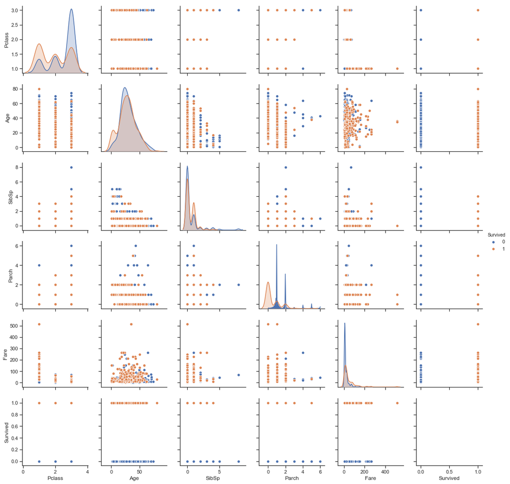

```python
import seaborn as sns
sns.set(style="ticks")
plotFeatures = [x for x in selFeatures]
plotFeatures.append("Survived")
sns.pairplot(trainData[plotFeatures], hue="Survived")
```

```python
targetClass = trainData.Survived.value_counts().values.tolist()
data = [go.Pie(labels=['Died','Survived'], values=targetClass,
              hoverinfo='label+percent', textinfo='value')]
layout = dict(
        title = "Comparison of Classes (Died/Survived)",
        autosize=False,
        width=500,
        height=500
    )

fig = dict(data=data, layout=layout)
iplot(fig)
```

[interactive chart not shown]

```python
def plotGraph(plotData,msg):
    trace1 = go.Bar(
    x=plotData.columns.values,
    y=plotData.values[0],
    name='No'
    )
    trace2 = go.Bar(
        x=plotData.columns.values,
        y=plotData.values[1],
        name='Yes'
    )
    data = [trace1, trace2]
    layout = dict(
        title = msg,
        xaxis= dict(title = plotData.columns.name),
        yaxis= dict(title= 'Number of people'),
        barmode='group',
        autosize=False,
        width=800,
        height=500
    )
    fig = dict(data=data, layout=layout)
    iplot(fig)
```

```python
pclass = pd.crosstab([trainData.Survived], trainData.Pclass)
plotGraph(pclass,'Survived based on Pclass')
```

[interactive chart not shown]

```python
sex = pd.crosstab([trainData.Survived], trainData.Sex)
plotGraph(sex, 'Survived based on sex')
```

[interactive chart not shown]

```python
embarked = pd.crosstab([trainData.Survived], trainData.Embarked)
plotGraph(embarked, 'Survived based on embarked')
```

[interactive chart not shown]

```python
SibSp = pd.crosstab([trainData.Survived], trainData.SibSp)
plotGraph(SibSp, 'Survived based on SibSp')
```

[interactive chart not shown]

```python
Parch = pd.crosstab([trainData.Survived], trainData.Parch)
plotGraph(Parch, 'Survived based on Parch')
```

[interactive chart not shown]

```python
def plotLine(plotData,msg):
    trace1 = go.Scatter(
    x=plotData.columns.values,
    y=plotData.values[0],
    mode='lines',
    name='No'
    )
    trace2 = go.Scatter(
        x=plotData.columns.values,
        y=plotData.values[1],
        mode='lines',
        name='Yes'
    )
    data = [trace1, trace2]
    layout = dict(
        title = msg,
        xaxis= dict(title = plotData.columns.name),
        yaxis= dict(title= 'Number of people'),
        autosize=False,
        width=800,
        height=500
    )
    fig = dict(data=data, layout=layout)
    iplot(fig)
```

```python
Age = pd.crosstab([trainData.Survived],trainData.Age)
plotLine(Age,'Survival based on Age')
```

[interactive chart not shown]

```python
Fare = pd.crosstab([trainData.Survived],trainData.Fare)
plotLine(Fare,'Survival based on Fare')
```

[interactive chart not shown]

## 3. Data Preparation

**3.1 Feature Selection**

Selecting the columns required for building the model based on EDA.

```python
# Also removing cabin and ticket features for the initial run.
selFeatures.remove('Ticket')

print("Target Class: '"+ targetCol + "'")
print('Features to be investigated: ')
print(selFeatures)
```

```
Target Class: 'Survived'
Features to be investigated:
['Pclass', 'Sex', 'Age', 'SibSp', 'Parch', 'Fare', 'Embarked']
```

```python
def handle_categorical_na(df):
    ## replacing the null/na/nan values in 'Cabin' attribute with 'X'
#     df.Cabin = df.Cabin.fillna(value='X')
#     ## Stripping the string data in 'Cabin' and 'Ticket' features of numeric values and duplicated characters
#     df.Cabin = [''.join(set(filter(str.isalpha, s))) for s in df.Cabin]
#     df.Ticket = [''.join(set(filter(str.isalpha, s))) for s in df.Ticket]
#     ## replacing the '' values in 'Ticket' attribute with 'X'
#     df.Ticket.replace(to_replace='',value='X',inplace=True)
    ## Imputing the null/na/nan values in 'Age' attribute with its mean value
    df.Age.fillna(value=df.Age.mean(),inplace=True)
    ## replacing the null/na/nan values in 'Embarked' attribute with 'X'
    df.Embarked.fillna(value='X',inplace=True)
    return df
```

```python
from sklearn.model_selection import train_test_split
seed = 7
np.random.seed(seed)
X_train, X_test, Y_train, Y_test = train_test_split(trainData[selFeatures], trainData.Survived, test_size=0.2)

X_train = handle_categorical_na(X_train)
X_test = handle_categorical_na(X_test)

## using One Hot Encoding for handling categorical data
X_train = pd.get_dummies(X_train,columns=['Embarked','Sex'],prefix=['Embarked','Sex'])
X_test = pd.get_dummies(X_test,columns=['Embarked','Sex'],prefix=['Embarked','Sex'])
```

```python
common_col = [x for x in X_test.columns if x in X_train.columns]
X_test = X_test[common_col]

missing_col = [x for x in X_train.columns if x not in X_test.columns]
## Inserting missing columns in test data
for val in missing_col:
    X_test.insert(X_test.shape[1], val, pd.Series(np.zeros(X_test.shape[0])))
```

## 4. Modeling

**4.1 Neural Network**

Using Sequential model of Keras API to build a neural network. The model is tuned and optimezed using Grid Serach.

The optimized parameters are:

- Number of neurons in input and hidden layers
- Activation type
- Optimizer
- Epochs
- Batch size
- Dropout ratio

Due to increased processing time, the best parameters were found and used.

```python
from sklearn.model_selection import GridSearchCV
from keras.models import Sequential
from keras.layers import Dense, Dropout
from keras.wrappers.scikit_learn import KerasClassifier
from keras.constraints import maxnorm

in_shape = X_train.shape[1]

def create_model(optimizer='Adam', neurons=50):
    # Initialize the constructor
    model = Sequential()
    # Input - Layer
    model.add(Dense(neurons, input_dim=in_shape, activation=activation))
    # Hidden - Layers
    model.add(Dropout(dropout_rate))
    model.add(Dense(neurons, activation = activation))
    model.add(Dropout(dropout_rate))
    model.add(Dense(neurons, activation = activation))
    # Output- Layer
    model.add(Dense(1, activation='sigmoid'))
    model.compile(loss='binary_crossentropy', optimizer=optimizer, metrics=['accuracy'])
    return model

def nn_hyperparameter_optimization():
    model = KerasClassifier(build_fn=create_model, verbose=0)
    # defining the grid search parameters
    neurons = [65, 75, 85]
    batch_size= [10, 20, 30, 40]
    epochs= [10, 20, 30, 40]
    optimizer = ['RMSprop', 'Adagrad', 'Adadelta', 'Adam', 'Adamax', 'Nadam']
    activation = ['softmax', 'softplus', 'softsign', 'relu', 'tanh', 'sigmoid', 'hard_sigmoid', 'linear']
    dropout_rate = [0.1, 0.2, 0.3, 0.4, 0.5]
    param_grid = dict(neurons=neurons,
                      optimizer=optimizer,
                      batch_size=batch_size,
                      epochs=epochs,
                      activation=activation,
                      dropout_rate=dropout_rate)
    grid = GridSearchCV(estimator=model, param_grid=param_grid, n_jobs=-1, cv=5)
    grid_result = grid.fit(X_train, Y_train)

    # summarize results
    print("Best: %f using %s" % (grid_result.best_score_, grid_result.best_params_))
    means = grid_result.cv_results_['mean_test_score']
    stds = grid_result.cv_results_['std_test_score']
    params = grid_result.cv_results_['params']
    for mean, stdev, param in zip(means, stds, params):
        print("%f (%f) with: %r" % (mean, stdev, param))
    return grid_result

## based on the hyper parameter optimization, the below model is built.
nn_model = Sequential()
# Input - Layer
nn_model.add(Dense(65, input_dim=in_shape, activation='relu'))
# Hidden - Layers
nn_model.add(Dropout(0.2))
nn_model.add(Dense(65, activation = 'relu'))
nn_model.add(Dropout(0.2))
nn_model.add(Dense(65, activation = 'relu'))
# Output- Layer
nn_model.add(Dense(1, activation='sigmoid'))
nn_model.compile(loss='binary_crossentropy', optimizer='Nadam', metrics=['accuracy'])
nn_model.fit(X_train, Y_train,
          batch_size=20,
          epochs=20,
          verbose=1,
          validation_data=(X_test, Y_test))

score = nn_model.evaluate(X_test, Y_test, verbose=2)
score_nn = score[1]
print('Test loss:', score[0])
print('Test accuracy:', score[1])
```

```
Train on 712 samples, validate on 179 samples
Test loss: 0.553673201766094
Test accuracy: 0.7541899431351177
```

**4.2 Random Forest**

Using Random Forest to build a model. The model uses Random Search to find the best hyperparameter values.

The optimized parameters are:

- Number of trees
- Number of features to consider at every split
- Maximum number of levels in tree
- Minimum number of samples required to split a node
- Minimum number of samples required at each leaf node
- Method of selecting samples for training each tree

```python
 def rf_hyperparameter_optimization():
    from sklearn.model_selection import RandomizedSearchCV
    # Number of trees in random forest
    n_estimators = [int(x) for x in np.linspace(start = 200, stop = 2000, num = 10)]
    # Number of features to consider at every split
    max_features = ['auto', 'sqrt']
    # Maximum number of levels in tree
    max_depth = [int(x) for x in np.linspace(10, 110, num = 11)]
    max_depth.append(None)
    # Minimum number of samples required to split a node
    min_samples_split = [2, 5, 10]
    # Minimum number of samples required at each leaf node
    min_samples_leaf = [1, 2, 4]
    # Method of selecting samples for training each tree
    bootstrap = [True, False]
    # Create the random grid
    random_grid = {'n_estimators': n_estimators,
                   'max_features': max_features,
                   'max_depth': max_depth,
                   'min_samples_split': min_samples_split,
                   'min_samples_leaf': min_samples_leaf,
                   'bootstrap': bootstrap}

    from sklearn.ensemble import RandomForestRegressor
    # Using the random grid to search for best hyperparameters
    # Creating the base model to tune
    rf = RandomForestRegressor()
    # Random search of parameters, using 5 fold cross validation,
    rf_random = RandomizedSearchCV(estimator = rf, param_distributions = random_grid, n_iter = 100, cv = 5, verbose=2, random_state=42, n_jobs = -1)
    # Fit the random search model
    rf_random.fit(X_train, Y_train)
    return rf_random.best_params_

## based on the hyper parameter optimization, the below model is built.
from sklearn.ensemble import RandomForestClassifier
rf_model = RandomForestClassifier(n_estimators=1400, min_samples_split=5, min_samples_leaf=4, max_features= 'sqrt', max_depth= 80, bootstrap= True)
rf_model.fit(X_train,Y_train)
# Fetching predictions
Y_pred = rf_model.predict(X_test)
# Calculating the test accuracy
from sklearn import metrics
score_rf = metrics.accuracy_score(Y_test, Y_pred)
print("Test Accuracy:",score_rf)
```

```
Test Accuracy: 0.776536312849162
```

**4.3 Submit Predictions**

Comparing the accuracy of neural network and random forest models and submitting the predictions from the best model.

```python
xTest = testData[selFeatures]
xTest = handle_categorical_na(xTest)
## using One Hot Encoding for handling categorical data
xTest = pd.get_dummies(xTest,columns=['Embarked','Sex'],prefix=['Embarked','Sex'])
common_col = [x for x in xTest.columns if x in X_train.columns]
xTest = xTest[common_col]
missing_col = [x for x in X_train.columns if x not in xTest.columns]
## Inserting missing columns in test data
for val in missing_col:
    xTest.insert(xTest.shape[1], val, pd.Series(np.zeros(xTest.shape[0])))
col_names = xTest.columns
from sklearn.impute import SimpleImputer
my_imputer = SimpleImputer()
xTest = my_imputer.fit_transform(xTest)
xTest = pd.DataFrame(xTest)
xTest.columns = col_names

submission = pd.DataFrame()
## Comparing and submitting the best result
if score_nn>score_rf:
    predictions = nn_model.predict_classes(xTest)
    predictions = [x[0] for x in predictions]
else:
    predictions = rf_model.predict(xTest)
submission = pd.DataFrame({'PassengerId': testData.PassengerId, 'Survived': predictions})
submission.to_csv('Data/submission.csv', index=False)
submission.head()
```

|  | PassengerId | Survived |
| --- | --- | --- |
| 0 | 892 | 0 |
| 1 | 893 | 0 |
| 2 | 894 | 0 |
| 3 | 895 | 0 |
| 4 | 896 | 1 |